# 📺 Netflix Content Analysis Using Python

## 📦 11. Movie Duration Box Plot

This box plot helps identify the spread of movie durations and highlights potential outliers.

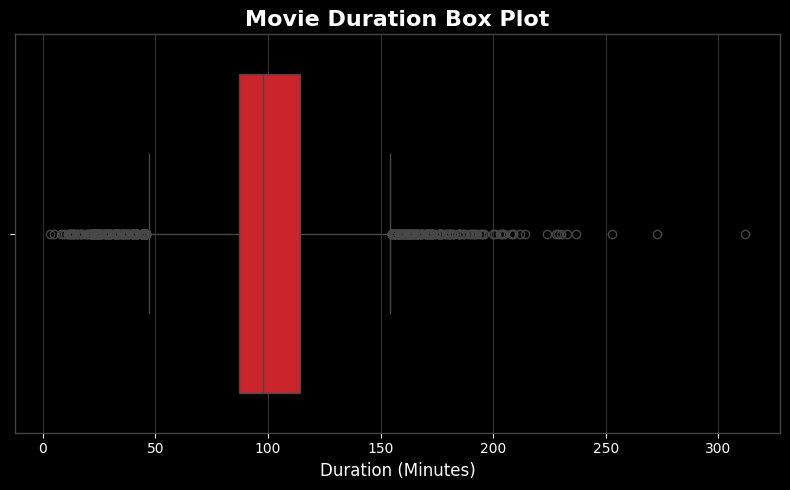

```python
plt.figure(figsize=(8,5))
sns.boxplot(x=movies['duration'], color=NETFLIX_RED)
plt.title("Movie Duration Box Plot", fontsize=16, fontweight='bold', color='white')
plt.xlabel("Duration (Minutes)")
plt.tight_layout()
plt.savefig("movie_duration_boxplot.png", dpi=300, bbox_inches='tight', facecolor='black')
plt.show()
```

### 💡 Insight

Most Netflix movies have a duration between **80 and 120 minutes**, while a few movies are significantly longer, appearing as outliers.

## 🔥 12. Missing Values Heatmap

This heatmap highlights missing values across the dataset.

[figure not shown]

```python
plt.figure(figsize=(12,6))
sns.heatmap(NETFLIX.isnull(), cbar=False, cmap='rocket')
plt.title("Missing Values Heatmap", fontsize=16, fontweight='bold', color='white')
plt.tight_layout()
plt.savefig("missing_values_heatmap.png", dpi=300, bbox_inches='tight', facecolor='black')
plt.show()
```

### 💡 Insight

Columns such as **Director**, **Cast**, and **Country** contain missing values, which should be considered during analysis.

This chart identifies the countries contributing the highest number of titles on Netflix.

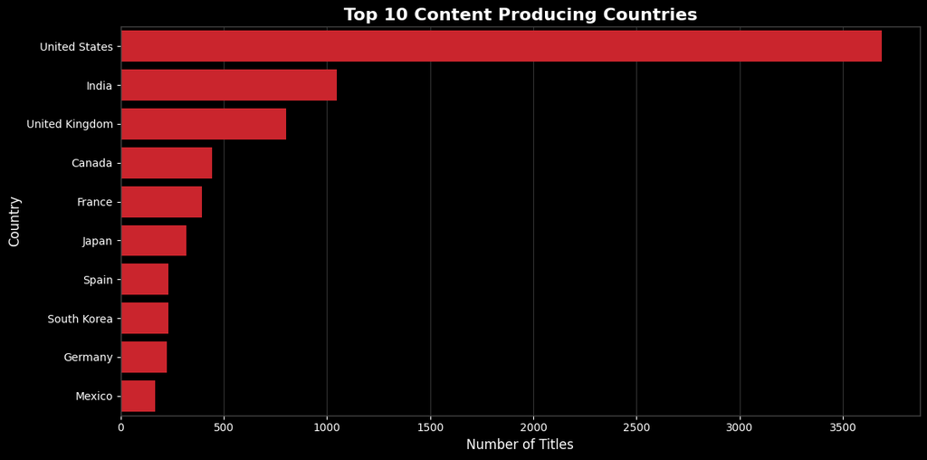

```python
country = NETFLIX['country'].dropna().str.split(', ').explode().value_counts().head(10)
plt.figure(figsize=(12,6))
sns.barplot(x=country.values, y=country.index, color=NETFLIX_RED)
plt.title("Top 10 Content Producing Countries", fontsize=16, fontweight='bold', color='white')
plt.xlabel("Number of Titles")
plt.ylabel("Country")
plt.tight_layout()
plt.savefig("top_10_countries_exploded.png", dpi=300, bbox_inches='tight', facecolor='black')
plt.show()
```

### 💡 Insight

The **United States** dominates Netflix's content library, followed by several countries contributing regional and international content.

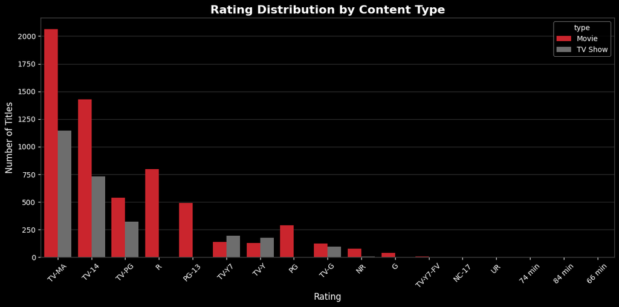

```python
plt.figure(figsize=(12,6))
sns.countplot(data=NETFLIX, x='rating', hue='type',
              order=NETFLIX['rating'].value_counts().index,
              palette=[NETFLIX_RED, '#6D6D6D'])
plt.xticks(rotation=45)
plt.title("Rating Distribution by Content Type", fontsize=16, fontweight='bold', color='white')
plt.xlabel("Rating")
plt.ylabel("Number of Titles")
plt.tight_layout()
plt.savefig("rating_by_type.png", dpi=300, bbox_inches='tight', facecolor='black')
plt.show()
```

### 💡 Insight

Movies dominate most rating categories, while TV Shows are concentrated in fewer rating classifications.

## 📅 15. Top Release Years

This chart shows the years with the highest number of content releases.

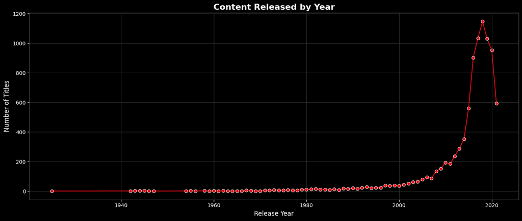

```python
release = NETFLIX['release_year'].value_counts().sort_index()
plt.figure(figsize=(14,6))
sns.lineplot(
    x=release.index,
    y=release.values,
    marker='o',
    color=NETFLIX_RED
)
plt.title("Content Released by Year", fontsize=16, fontweight='bold', color='white')
plt.xlabel("Release Year")
plt.ylabel("Number of Titles")
plt.tight_layout()
plt.savefig("release_year_trend.png", dpi=300, bbox_inches='tight', facecolor='black')
plt.show()
```

### 💡 Insight

Netflix's content production and acquisitions increased significantly in recent years, reflecting its rapid global expansion.

## 🎭 16. Top 10 Actors on Netflix

This visualization shows the actors who have appeared in the highest number of Netflix titles.

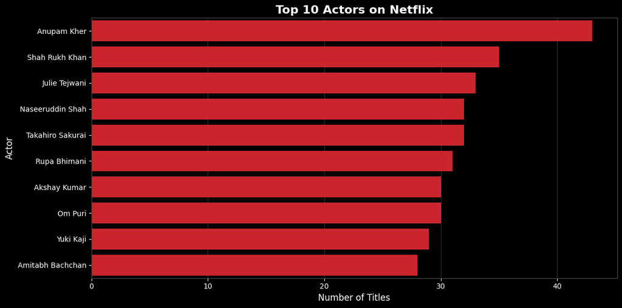

```python
actors = (
    NETFLIX['cast']
    .dropna()
    .str.split(', ')
    .explode()
    .value_counts()
    .head(10)
)
plt.figure(figsize=(12,6))
sns.barplot(
    x=actors.values,
    y=actors.index,
    color=NETFLIX_RED
)
plt.title("Top 10 Actors on Netflix", fontsize=16, fontweight='bold', color='white')
plt.xlabel("Number of Titles")
plt.ylabel("Actor")
plt.tight_layout()
plt.savefig("top_10_actors.png", dpi=300, bbox_inches='tight', facecolor='black')
plt.show()
```

### 💡 Business Insight

A small group of actors appears frequently across Netflix titles, highlighting recurring collaborations.

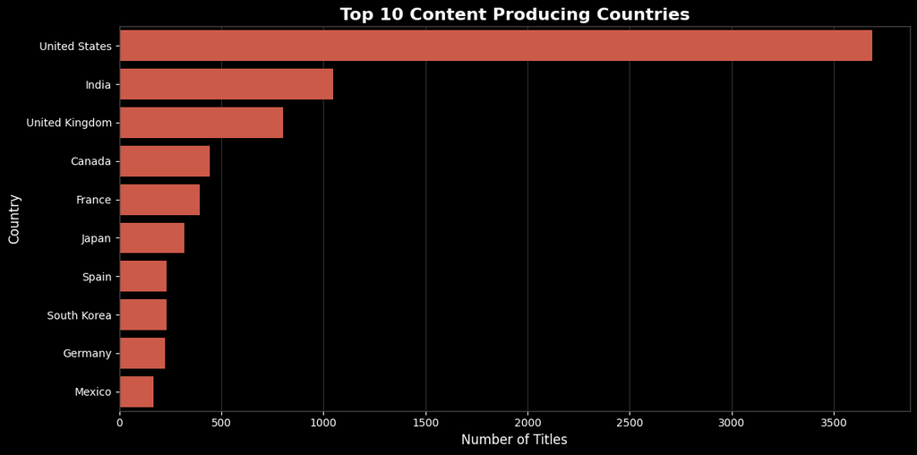

```python
country = (
    NETFLIX['country']
    .dropna()
    .str.split(', ')
    .explode()
    .value_counts()
    .head(10)
)

plt.figure(figsize=(12,6))

sns.barplot(
    x=country.values,
    y=country.index
)

plt.title("Top 10 Content Producing Countries", fontsize=16, fontweight='bold')
plt.xlabel("Number of Titles")
plt.ylabel("Country")

plt.tight_layout()
plt.show()
```

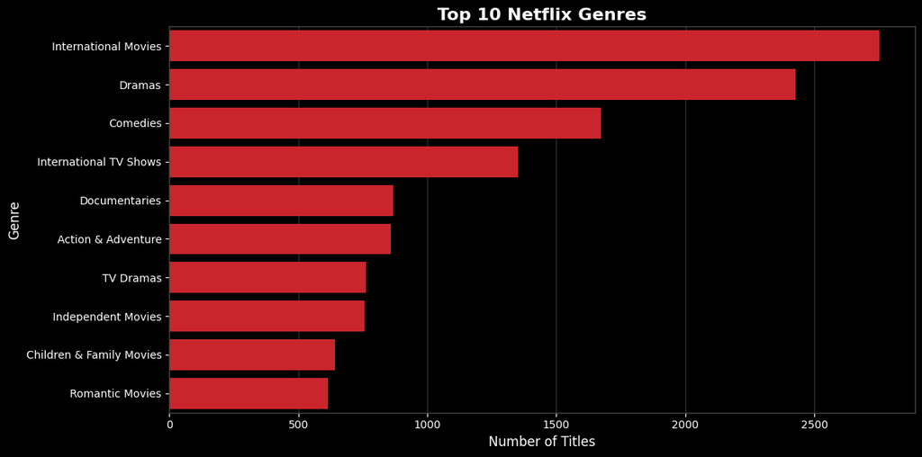

```python
genre = NETFLIX['listed_in'].dropna().str.split(', ').explode().value_counts().head(10)
plt.figure(figsize=(12,6))
sns.barplot(x=genre.values, y=genre.index, color=NETFLIX_RED)
plt.title("Top 10 Netflix Genres", fontsize=16, fontweight='bold', color='white')
plt.xlabel("Number of Titles")
plt.ylabel("Genre")
plt.tight_layout()
plt.savefig("top_10_genres_exploded.png", dpi=300, bbox_inches='tight', facecolor='black')
plt.show()
```

```python
print(NETFLIX.columns.tolist())
```

[output not shown]

```python
NETFLIX['date_added'] = pd.to_datetime(NETFLIX['date_added'], errors='coerce')
NETFLIX['year_added'] = NETFLIX['date_added'].dt.year
NETFLIX['month_added'] = NETFLIX['date_added'].dt.month_name()

print(NETFLIX.columns.tolist())
```

```
['show_id', 'type', 'title', 'director', 'cast', 'country', 'date_added', 'release_year', 'rating', 'duration', 'listed_in', 'description', 'year_added', 'month_added']
```

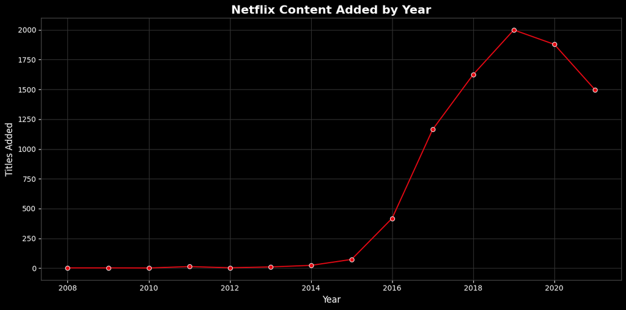

```python
year_added = NETFLIX['year_added'].value_counts().sort_index()
plt.figure(figsize=(12,6))
sns.lineplot(x=year_added.index, y=year_added.values, marker='o', color=NETFLIX_RED)
plt.title("Netflix Content Added by Year", fontsize=16, fontweight='bold', color='white')
plt.xlabel("Year")
plt.ylabel("Titles Added")
plt.tight_layout()
plt.savefig("content_added_by_year.png", dpi=300, bbox_inches='tight', facecolor='black')
plt.show()
```

```python
print("="*50)
print(" NETFLIX DATASET SUMMARY ")
print("="*50)

print(f"Total Titles      : {len(NETFLIX)}")
print(f"Movies            : {len(movies)}")
print(f"TV Shows          : {len(tvshows)}")
print(f"Countries         : {NETFLIX['country'].nunique()}")
print(f"Directors         : {NETFLIX['director'].nunique()}")
print(f"Genres            : {genre.shape[0]}")
print(f"Ratings           : {NETFLIX['rating'].nunique()}")
print(f"Release Years     : {NETFLIX['release_year'].nunique()}")
```

[output not shown]

# 💡 Key Business Insights

- Movies make up the majority of Netflix's content library.
- The United States contributes the highest number of titles.
- Drama and International Movies are among the most popular genres.
- Netflix experienced rapid growth in content additions after 2015.
- TV-MA is the most common content rating.
- Most movies have a duration between 80 and 120 minutes.
- A small number of actors and directors appear frequently across Netflix titles.
- Netflix has significantly expanded its global content catalog over the years.

# 📝 Conclusion

This project analyzed the Netflix Movies and TV Shows dataset using Python, Pandas, NumPy, Matplotlib, and Seaborn.

The analysis revealed that Movies dominate Netflix's content library, with the United States leading in content production. Drama and International Movies are among the most popular genres, while TV-MA is the most common content rating. Netflix's content catalog has grown rapidly since 2015, reflecting its expansion into global markets.

These insights demonstrate how exploratory data analysis and visualization can uncover valuable business trends from real-world datasets.

# 🚀 Recommendations

- Expand content production in emerging markets.
- Increase investment in high-performing genres.
- Continue growing international content.
- Improve family-friendly content offerings.
- Use audience preferences to guide future content strategies.